# Status loss and participation

## CEM comments: activity adjustment 2

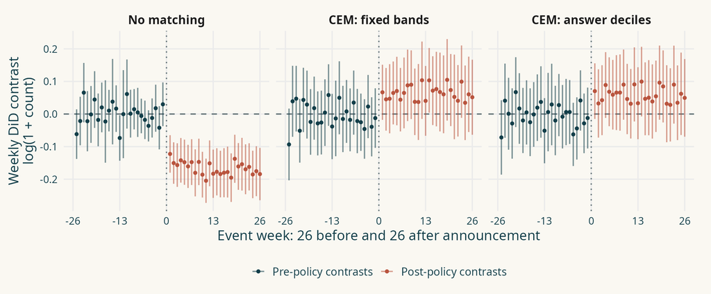

Same CEM weights, input window and regression-DiD estimator; simultaneous 95% bands within model.

Same CEM weights, input window and regression-DiD estimator; simultaneous 95% bands within model.

Inspect pre diagnostics and post estimates; no joint correction across all specifications.

## Activity sensitivity: days with other contributions

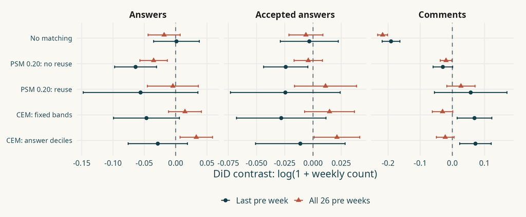

All primary PSM and CEM designs; both references; same ±26 window. 1,000 user multiplier replications; 95% pointwise intervals.

All primary PSM and CEM designs; both references; same ±26 window. 1,000 user multiplier replications; 95% pointwise intervals.

The contemporary activity control can respond to treatment; this is a conditional comparison.

## PSM without control reuse: activity adjustment 3

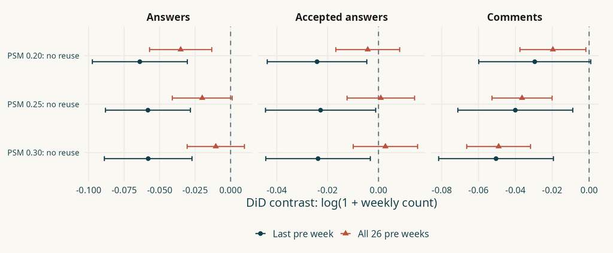

All three calipers have fitted outcome models under this adjustment; both time references; ±26 weeks.

All three calipers have fitted outcome models under this adjustment; both time references; ±26 weeks.

A changed caliper changes retained users and weights, as well as precision.

## PSM with control reuse: activity adjustment 3

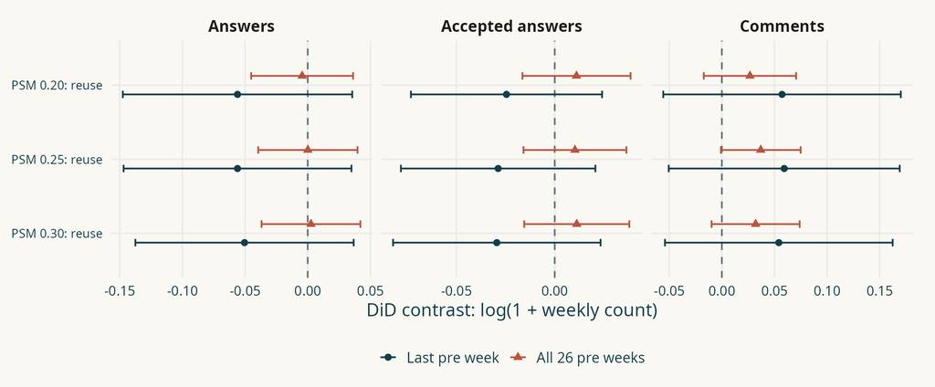

All three calipers have fitted outcome models under this adjustment; both time references; ±26 weeks.

All three calipers have fitted outcome models under this adjustment; both time references; ±26 weeks.

A changed caliper changes retained users and weights, as well as precision.

## CEM answers: activity adjustment 3

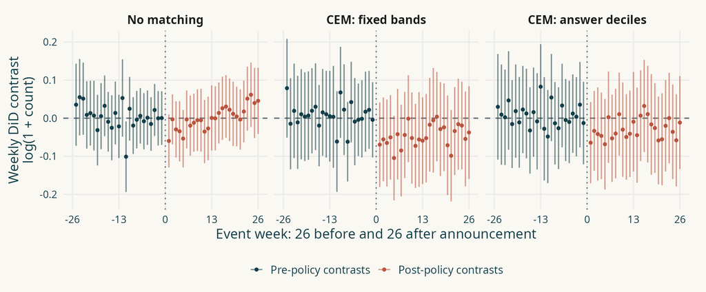

Same CEM weights, input window and regression-DiD estimator; simultaneous 95% bands within model.

Same CEM weights, input window and regression-DiD estimator; simultaneous 95% bands within model.

Inspect pre diagnostics and post estimates; no joint correction across all specifications.

## CEM accepted answers: activity adjustment 3

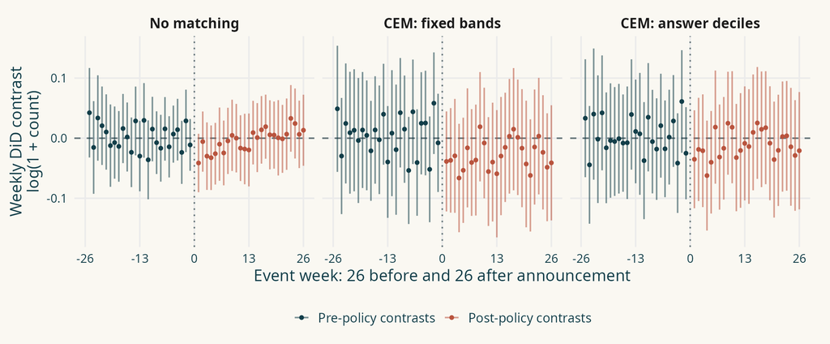

Same CEM weights, input window and regression-DiD estimator; simultaneous 95% bands within model.

Same CEM weights, input window and regression-DiD estimator; simultaneous 95% bands within model.

Inspect pre diagnostics and post estimates; no joint correction across all specifications.

## CEM comments: activity adjustment 3

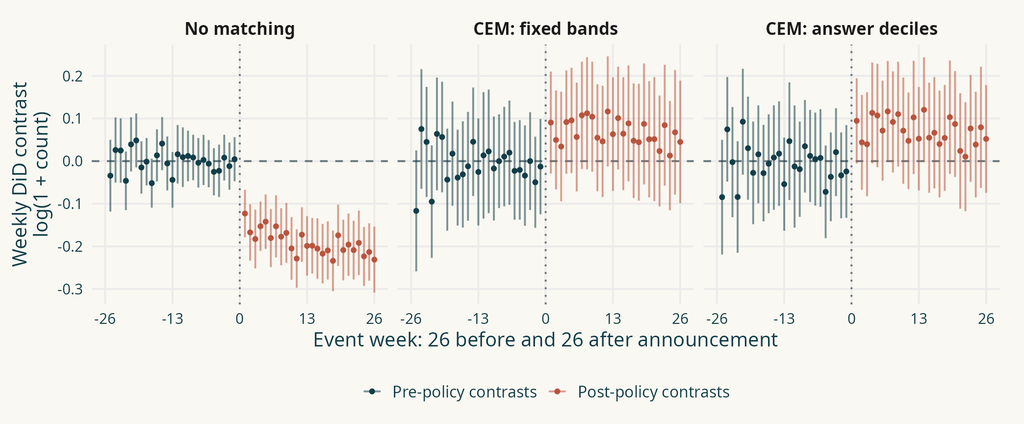

Same CEM weights, input window and regression-DiD estimator; simultaneous 95% bands within model.

Same CEM weights, input window and regression-DiD estimator; simultaneous 95% bands within model.

Inspect pre diagnostics and post estimates; no joint correction across all specifications.

## Calipers: answers · no control reuse

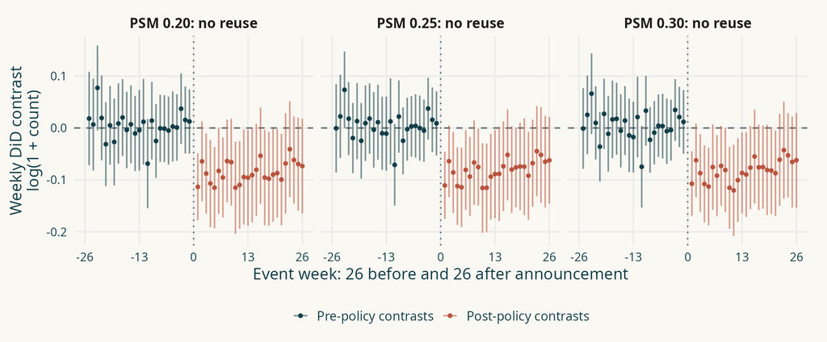

Estimated weekly outcome comparisons at all three calipers; full ±26 input window; simultaneous 95% bands within model.

Estimated weekly outcome comparisons at all three calipers; full ±26 input window; simultaneous 95% bands within model.

The same user may enter some matched designs and be excluded from others.

## Calipers: accepted answers · no control reuse

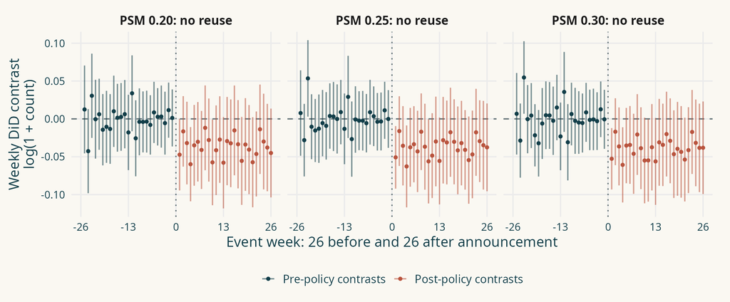

Estimated weekly outcome comparisons at all three calipers; full ±26 input window; simultaneous 95% bands within model.

Estimated weekly outcome comparisons at all three calipers; full ±26 input window; simultaneous 95% bands within model.

The same user may enter some matched designs and be excluded from others.

## Calipers: comments · no control reuse

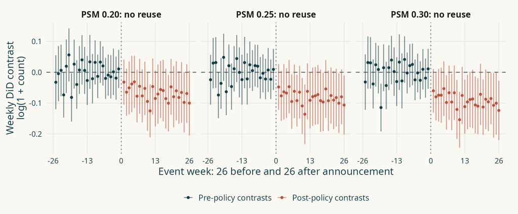

Estimated weekly outcome comparisons at all three calipers; full ±26 input window; simultaneous 95% bands within model.

Estimated weekly outcome comparisons at all three calipers; full ±26 input window; simultaneous 95% bands within model.

The same user may enter some matched designs and be excluded from others.

## Calipers: answers · control reuse allowed

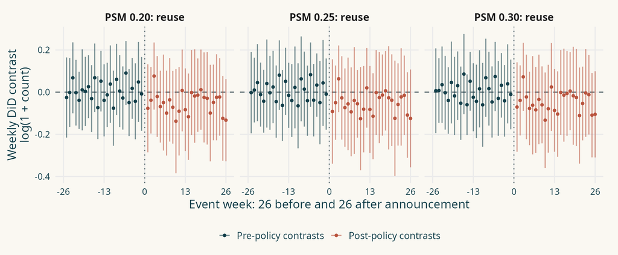

Estimated weekly outcome comparisons at all three calipers; full ±26 input window; simultaneous 95% bands within model.

Estimated weekly outcome comparisons at all three calipers; full ±26 input window; simultaneous 95% bands within model.

The same user may enter some matched designs and be excluded from others.

## Calipers: accepted answers · control reuse allowed

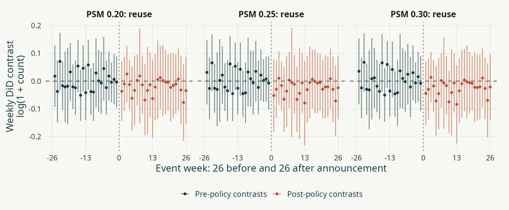

Estimated weekly outcome comparisons at all three calipers; full ±26 input window; simultaneous 95% bands within model.

Estimated weekly outcome comparisons at all three calipers; full ±26 input window; simultaneous 95% bands within model.

The same user may enter some matched designs and be excluded from others.

## Calipers: comments · control reuse allowed

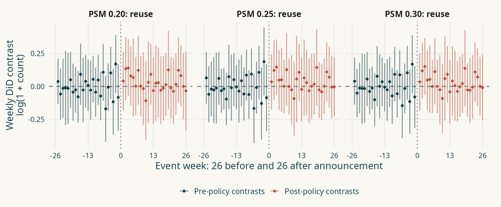

Estimated weekly outcome comparisons at all three calipers; full ±26 input window; simultaneous 95% bands within model.

Estimated weekly outcome comparisons at all three calipers; full ±26 input window; simultaneous 95% bands within model.

The same user may enter some matched designs and be excluded from others.

## Covariate means: PSM 0.25: no reuse

| Covariate | Before: treated | Before: controls | After: treated | After: controls | Mean gap after matching | Standardized gap: before → after |
| --- | --- | --- | --- | --- | --- | --- |
| Prior comments | 9.59 | 1.78 | 2.61 | 1.72 | +0.89 | +0.241 → +0.027 |
| Prior answers | 10.85 | 3.88 | 3.69 | 3.72 | -0.03 | +0.170 → -0.001 |
| Prior reputation | 306.15 | 73.58 | 92.60 | 72.85 | +19.75 | +0.218 → +0.018 |
| Tenure (weeks) | 26.93 | 19.08 | 22.02 | 21.71 | +0.31 | +0.470 → +0.018 |

After matching: **35,144 treated / 35,144 distinct controls**. Effective controls: 35,144.

Original units; weighted means after matching. Before matching: 49,588 treated and 47,071 controls. Column definitions.

## Covariate means: PSM 0.25: reuse

| Covariate | Before: treated | Before: controls | After: treated | After: controls | Mean gap after matching | Standardized gap: before → after |
| --- | --- | --- | --- | --- | --- | --- |
| Prior comments | 9.59 | 1.78 | 5.43 | 5.09 | +0.33 | +0.241 → +0.010 |
| Prior answers | 10.85 | 3.88 | 5.86 | 5.90 | -0.04 | +0.170 → -0.001 |
| Prior reputation | 306.15 | 73.58 | 167.68 | 162.81 | +4.87 | +0.218 → +0.005 |
| Tenure (weeks) | 26.93 | 19.08 | 26.53 | 26.45 | +0.08 | +0.470 → +0.005 |

After matching: **48,018 treated / 10,369 distinct controls**. Effective controls: 1,651.

Original units; weighted means after matching. Before matching: 49,588 treated and 47,071 controls. Column definitions.

## Covariate means: PSM 0.30: no reuse

| Covariate | Before: treated | Before: controls | After: treated | After: controls | Mean gap after matching | Standardized gap: before → after |
| --- | --- | --- | --- | --- | --- | --- |
| Prior comments | 9.59 | 1.78 | 2.72 | 1.70 | +1.02 | +0.241 → +0.032 |
| Prior answers | 10.85 | 3.88 | 3.74 | 3.75 | -0.00 | +0.170 → -0.000 |
| Prior reputation | 306.15 | 73.58 | 94.71 | 72.56 | +22.15 | +0.218 → +0.021 |
| Tenure (weeks) | 26.93 | 19.08 | 22.38 | 21.58 | +0.79 | +0.470 → +0.047 |

After matching: **36,478 treated / 36,478 distinct controls**. Effective controls: 36,478.

Original units; weighted means after matching. Before matching: 49,588 treated and 47,071 controls. Column definitions.

## Covariate means: PSM 0.30: reuse

| Covariate | Before: treated | Before: controls | After: treated | After: controls | Mean gap after matching | Standardized gap: before → after |
| --- | --- | --- | --- | --- | --- | --- |
| Prior comments | 9.59 | 1.78 | 5.71 | 5.34 | +0.36 | +0.241 → +0.011 |
| Prior answers | 10.85 | 3.88 | 6.16 | 6.23 | -0.06 | +0.170 → -0.002 |
| Prior reputation | 306.15 | 73.58 | 175.80 | 171.42 | +4.39 | +0.218 → +0.004 |
| Tenure (weeks) | 26.93 | 19.08 | 26.59 | 26.51 | +0.08 | +0.470 → +0.005 |

After matching: **48,282 treated / 10,395 distinct controls**. Effective controls: 1,670.

Original units; weighted means after matching. Before matching: 49,588 treated and 47,071 controls. Column definitions.

## Observed weekly counts: answers

| Design | Treated: pre | Treated: post | Controls: pre | Controls: post |
| --- | --- | --- | --- | --- |
| No matching | 1.68 | 1.65 | 1.67 | 2.12 |
| PSM 0.20: no reuse | 0.94 | 1.12 | 1.37 | 1.85 |
| PSM 0.20: reuse | 0.95 | 1.08 | 1.32 | 1.51 |
| CEM: fixed bands | 2.66 | 2.30 | 3.42 | 2.97 |
| CEM: answer deciles | 2.55 | 2.22 | 3.48 | 2.99 |

These are observed group means in original counts. A level difference is not the estimated DiD effect.

Same ±26 window; design-weighted user-week means, then equal weight to each observed group-week. Original active-week definition; no added inactive weeks.

## Observed weekly counts: accepted answers

| Design | Treated: pre | Treated: post | Controls: pre | Controls: post |
| --- | --- | --- | --- | --- |
| No matching | 0.50 | 0.59 | 0.43 | 0.71 |
| PSM 0.20: no reuse | 0.23 | 0.35 | 0.38 | 0.62 |
| PSM 0.20: reuse | 0.26 | 0.36 | 0.40 | 0.52 |
| CEM: fixed bands | 0.75 | 0.79 | 1.08 | 1.11 |
| CEM: answer deciles | 0.72 | 0.78 | 1.07 | 1.10 |

These are observed group means in original counts. A level difference is not the estimated DiD effect.

Same ±26 window; design-weighted user-week means, then equal weight to each observed group-week. Original active-week definition; no added inactive weeks.

## Observed counts with CEM: answers

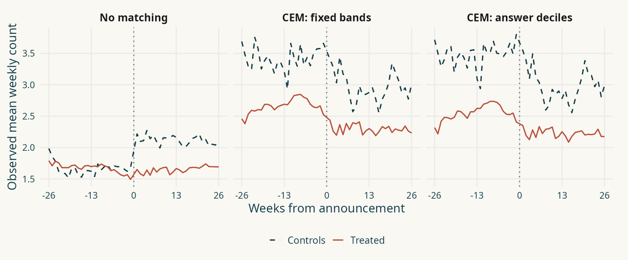

Weighted observed weekly means in original counts; 26 weeks on either side; no added inactive weeks.

Weighted observed weekly means in original counts; 26 weeks on either side; no added inactive weeks.

These are descriptive levels, not treatment-effect estimates.

## Observed counts with CEM: accepted answers

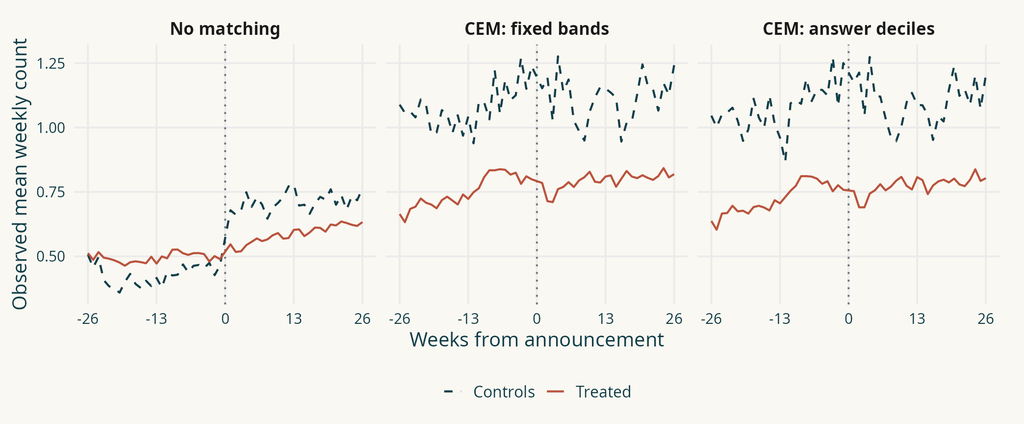

Weighted observed weekly means in original counts; 26 weeks on either side; no added inactive weeks.

Weighted observed weekly means in original counts; 26 weeks on either side; no added inactive weeks.

These are descriptive levels, not treatment-effect estimates.

## Observed counts with CEM: comments

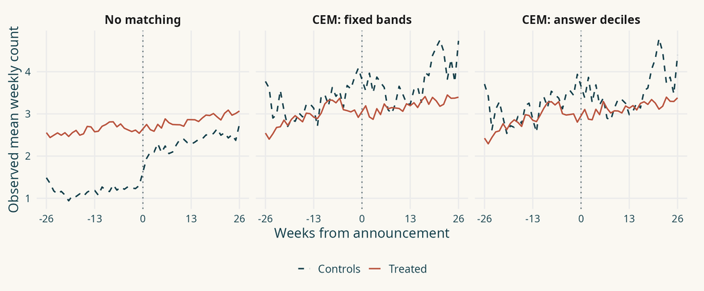

Weighted observed weekly means in original counts; 26 weeks on either side; no added inactive weeks.

Weighted observed weekly means in original counts; 26 weeks on either side; no added inactive weeks.

These are descriptive levels, not treatment-effect estimates.

## The original continuous models: GAM and linear

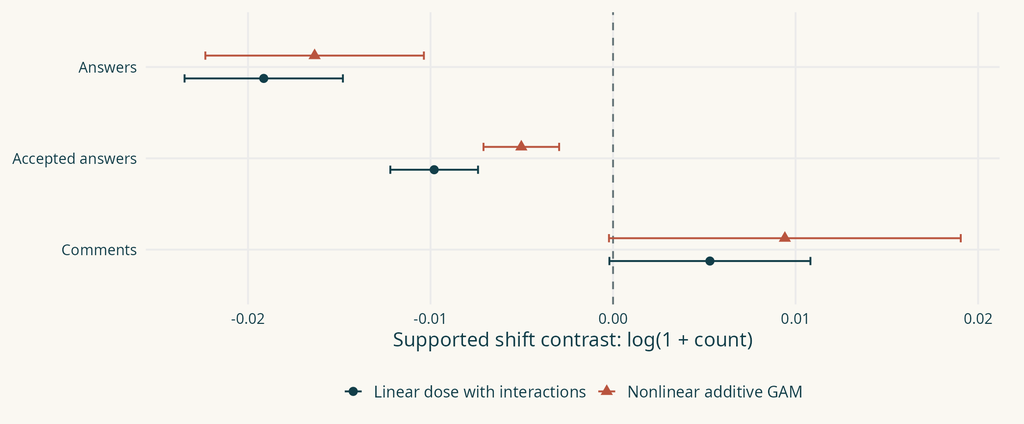

Both models re-estimated using all 26 pre / 26 post weeks; same +15-pp supported target. 200 user bootstrap resamples.

Both models re-estimated using all 26 pre / 26 post weeks; same +15-pp supported target. 200 user bootstrap resamples.

Curvature and interactions differ; keep the models’ assumptions explicit.

## Continuous DiD slope: stronger assumptions are needed

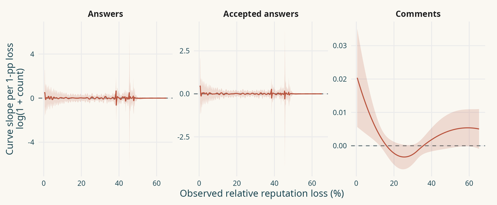

Derivative per 1-pp loss; official CCK method; ±26 activity means; 999 Gaussian multiplier replications; uniform 95% bands.

Derivative per 1-pp loss; official CCK method; ±26 activity means; 999 Gaussian multiplier replications; uniform 95% bands.

The curve slope is not the finite +15-pp shift; its causal-response interpretation requires stronger assumptions.